# Quick Start: End-to-End Workflow

- Show All Code
- Hide All Code
- View Source

Complete lifecycle — conformal regression, classification, DistributionPrediction API, persistence, and validation strategies

Published

May 11, 2026

# Quick Start: End-to-End Workflow

1. Choosing the right validation strategy
2. Conformal regression (tabular)
3. The full `DistributionPrediction` API
4. Parametric distribution fitting
5. Comprehensive evaluation
6. Model persistence (save / load)
7. Conformal classification

## Setup

```python
import polars as pl
import numpy as np
import matplotlib.pyplot as plt
from sklearn.ensemble import GradientBoostingRegressor, RandomForestClassifier

from uncertainty_flow import (
    ConformalRegressor,
    ConformalClassifier,
    coverage_score,
    winkler_score,
    pinball_loss,
)
from uncertainty_flow.utils import select_validation_plan
```

## Validation Strategy

Choosing the right train/test split matters. `select_validation_plan()` inspects your data shape and task type, then recommends a split strategy.

```python
df = pl.read_parquet("../data/concrete.parquet")
print(f"Shape: {df.shape}")
df.head(3)
```

```
Shape: (1030, 9)
```

shape: (3, 9)

| cement f64 | slag f64 | ash f64 | water f64 | superplastic f64 | coarseagg f64 | fineagg f64 | age i64 | strength f64 |
| --- | --- | --- | --- | --- | --- | --- | --- | --- |
| 540.0 | 0.0 | 0.0 | 162.0 | 2.5 | 1040.0 | 676.0 | 28 | 79.99 |
| 540.0 | 0.0 | 0.0 | 162.0 | 2.5 | 1055.0 | 676.0 | 28 | 61.89 |
| 332.5 | 142.5 | 0.0 | 228.0 | 0.0 | 932.0 | 594.0 | 270 | 40.27 |

```python
plan = select_validation_plan(df, task_type="tabular")
print(plan.metadata.strategy_name)
```

```
random_holdout
```

The plan provides ready-to-use splits:

```python
train_df, test_df = plan.outer_split
print(f"Train: {len(train_df)}  Test: {len(test_df)}")
```

```
Train: 824  Test: 206
```

For small datasets (<250 rows), the plan automatically recommends cross-validation instead of holdout.

## Conformal Regression

Wrap any scikit-learn regressor with distribution-free coverage guarantees:

```python
model = ConformalRegressor(
    base_model=GradientBoostingRegressor(random_state=42),
    coverage_target=0.9,
)
model.fit(train_df, target="strength")
```

```
<uncertainty_flow.wrappers.conformal.ConformalRegressor at 0x1171a42f0>
```

```python
pred = model.predict(test_df)
```

## DistributionPrediction API

Every predict call returns a `DistributionPrediction`. Here’s the full surface:

### Intervals & Quantiles

```python
intervals = pred.interval(confidence=0.9)
print(intervals.head())
```

```
shape: (5, 2)
┌───────────┬───────────┐
│ lower     ┆ upper     │
│ ---       ┆ ---       │
│ f64       ┆ f64       │
╞═══════════╪═══════════╡
│ 22.110626 ┆ 44.408737 │
│ 32.811675 ┆ 55.109786 │
│ 18.645393 ┆ 40.943503 │
│ 29.667123 ┆ 51.965233 │
│ 45.17357  ┆ 67.471681 │
└───────────┴───────────┘
```

```python
quantiles = pred.quantile([0.1, 0.5, 0.9])
print(quantiles.head())
```

```
shape: (5, 3)
┌───────────┬───────────┬───────────┐
│ q_0.100   ┆ q_0.500   ┆ q_0.900   │
│ ---       ┆ ---       ┆ ---       │
│ f64       ┆ f64       ┆ f64       │
╞═══════════╪═══════════╪═══════════╡
│ 23.734416 ┆ 28.761976 ┆ 36.783354 │
│ 34.435465 ┆ 39.463025 ┆ 47.484402 │
│ 20.269182 ┆ 25.296742 ┆ 33.31812  │
│ 31.290912 ┆ 36.318472 ┆ 44.33985  │
│ 46.79736  ┆ 51.82492  ┆ 59.846298 │
└───────────┴───────────┴───────────┘
```

```python
pred.median().head()
```

shape: (10,)

| median f64 |
| --- |
| 28.761976 |
| 39.463025 |
| 25.296742 |
| 36.318472 |
| 51.82492 |
| 57.929891 |
| 48.490284 |
| 52.308695 |
| 46.745018 |
| 51.696277 |

### Sampling

Draw synthetic samples from the predicted distribution:

```python
samples = pred.sample(n=500, random_state=42)
print(samples.shape)
samples.head()
```

```
(103000, 2)
```

shape: (5, 2)

| sample_id i64 | strength f64 |
| --- | --- |
| 0 | 32.02114 |
| 0 | 28.191501 |
| 0 | 35.005991 |
| 0 | 30.654094 |
| 0 | 23.54532 |

### Summary

One-row overview of the entire prediction distribution:

```python
pred.summary()
```

shape: (1, 7)

| target str | median f64 | mean_width_90 f64 | mean_width_50 f64 | aleatoric f64 | epistemic f64 | total_uncertainty f64 |
| --- | --- | --- | --- | --- | --- | --- |
| "strength" | 45.814013 | 22.298111 | 4.885196 | 22.298111 | 1.2377e-29 | 22.298111 |

### Parametric Distribution Fitting

Fit a parametric distribution (normal, Student-t, lognormal, gamma) to the quantile predictions:

```python
dist = pred.fit_distribution(family="auto")
print(dist)
print(f"  Mean: {dist.mean:.2f}  Variance: {dist.variance:.2f}")
```

```
ParametricDistribution(family='lognormal', s=0.76, loc=38.86, scale=6.16)
  Mean: 47.09  Variance: 52.86
```

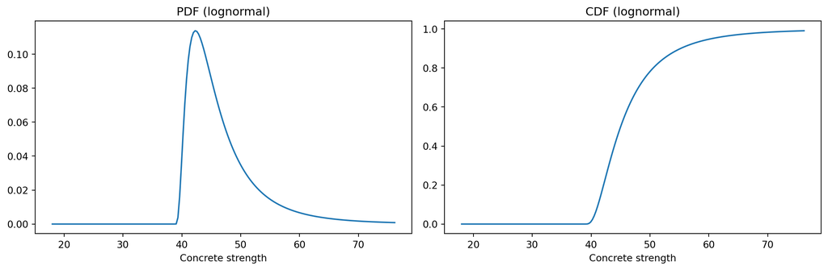

```python
fig, axes = plt.subplots(1, 2, figsize=(12, 4))

x = np.linspace(dist.mean - 4 * np.sqrt(dist.variance),
                dist.mean + 4 * np.sqrt(dist.variance), 200)

axes[0].plot(x, dist.pdf(x))
axes[0].set_title(f"PDF ({dist.family})")
axes[0].set_xlabel("Concrete strength")

axes[1].plot(x, dist.cdf(x))
axes[1].set_title(f"CDF ({dist.family})")
axes[1].set_xlabel("Concrete strength")

plt.tight_layout()
plt.show()
```

## Comprehensive Evaluation

```python
y_true = test_df["strength"]
intv = pred.interval(0.9)

results = {
    "coverage_90": coverage_score(y_true, intv["lower"], intv["upper"]),
    "winkler_90": winkler_score(y_true, intv["lower"], intv["upper"], 0.9),
    "pinball_50": pinball_loss(y_true, pred.median(), 0.5),
    "crps": pred.crps(y_true),
    "log_score": pred.log_score(y_true),
}

for name, value in results.items():
    print(f"  {name:20s}: {value:.4f}")
```

```
  coverage_90         : 0.2621
  winkler_90          : 187.6153
  pinball_50          : 7.2306
  crps                : 11.7422
  log_score           : -3.6070
```

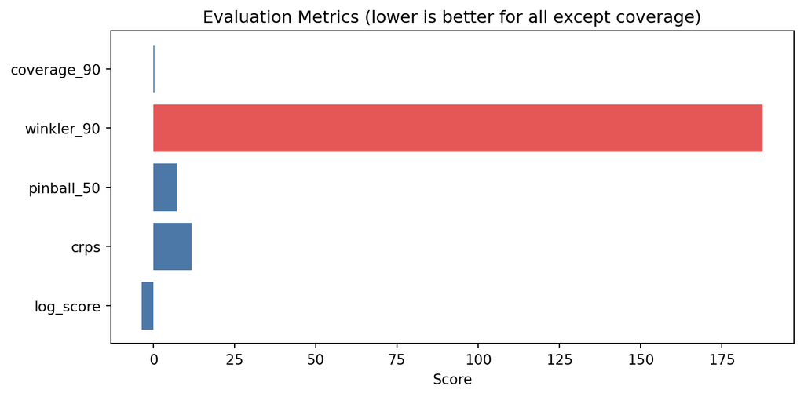

```python
fig, ax = plt.subplots(figsize=(8, 4))
names = list(results.keys())
values = list(results.values())
colors = ["#4C78A8" if v != max(values) else "#E45756" for v in values]
ax.barh(names, values, color=colors)
ax.set_xlabel("Score")
ax.set_title("Evaluation Metrics (lower is better for all except coverage)")
ax.invert_yaxis()
plt.tight_layout()
plt.show()
```

## Visualization

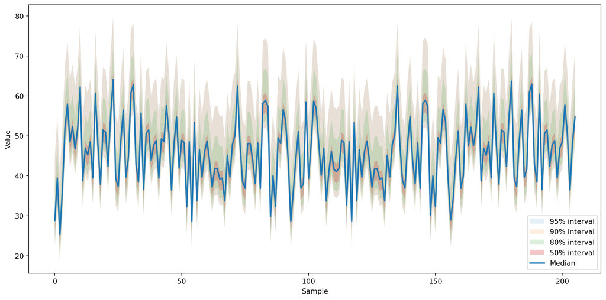

```python
pred.plot()
plt.show()
```

## Persistence

Save and reload models with the `.uf` archive format:

```python
import tempfile
import os

with tempfile.TemporaryDirectory() as tmpdir:
    path = os.path.join(tmpdir, "concrete_model.uf")
    model.save(path)
    print(f"Saved to {path}")

    loaded = ConformalRegressor.load(path)
    pred_loaded = loaded.predict(test_df)

    assert np.allclose(
        pred._quantiles, pred_loaded._quantiles
    ), "Predictions differ after reload!"
    print("Verification passed: predictions identical after save/load round-trip")
```

```
Saved to /var/folders/zv/p_57kc9j1fb9xtj06cw1qb1c0000gn/T/tmpdi13zxuh/concrete_model.uf
Verification passed: predictions identical after save/load round-trip
```

## Conformal Classification

The library also supports conformal prediction for classification tasks via `ConformalClassifier`, which produces `PredictionSet` objects with guaranteed marginal coverage.

```python
wine = pl.read_parquet("../data/wine_quality.parquet")
print(f"Shape: {wine.shape}")
print(f"Classes: {wine['quality'].unique().sort().to_list()}")
wine.head(3)
```

```
Shape: (1599, 12)
Classes: [3, 4, 5, 6, 7, 8]
```

shape: (3, 12)

| fixed acidity f64 | volatile acidity f64 | citric acid f64 | residual sugar f64 | chlorides f64 | free sulfur dioxide f64 | total sulfur dioxide f64 | density f64 | pH f64 | sulphates f64 | alcohol f64 | quality i64 |
| --- | --- | --- | --- | --- | --- | --- | --- | --- | --- | --- | --- |
| 7.4 | 0.7 | 0.0 | 1.9 | 0.076 | 11.0 | 34.0 | 0.9978 | 3.51 | 0.56 | 9.4 | 5 |
| 7.8 | 0.88 | 0.0 | 2.6 | 0.098 | 25.0 | 67.0 | 0.9968 | 3.2 | 0.68 | 9.8 | 5 |
| 7.8 | 0.76 | 0.04 | 2.3 | 0.092 | 15.0 | 54.0 | 0.997 | 3.26 | 0.65 | 9.8 | 5 |

```python
plan_cls = select_validation_plan(wine, task_type="tabular")
train_w, test_w = plan_cls.outer_split

clf = ConformalClassifier(
    base_model=RandomForestClassifier(random_state=42, n_estimators=100),
    coverage_target=0.9,
)
clf.fit(train_w, target="quality")
pred_set = clf.predict(test_w)
```

```python
print(pred_set)
print(f"\nCoverage target: {pred_set.coverage}")
print(f"Average set size: {pred_set.size:.2f} (out of {len(clf._class_names_)} classes)")
```

```
PredictionSet(n_samples=319, n_classes=6, coverage=0.90, avg_size=3.12)

Coverage target: 0.9
Average set size: 3.12 (out of 6 classes)
```

```python
print("Sample prediction sets (first 5):")
for i in range(5):
    classes = pred_set.set(i)
    probs = pred_set.probabilities()
    print(f"  Sample {i}: {classes}")
```

```
Sample prediction sets (first 5):
  Sample 0: [np.int64(6), np.int64(5), np.int64(4)]
  Sample 1: [np.int64(6), np.int64(5), np.int64(4)]
  Sample 2: [np.int64(6), np.int64(5), np.int64(7), np.int64(4)]
  Sample 3: [np.int64(6), np.int64(5)]
  Sample 4: [np.int64(6), np.int64(7), np.int64(5)]
```

```python
pred_set.summary()
```

shape: (1, 4)

| coverage_target f64 | avg_set_size f64 | n_samples i64 | n_classes i64 |
| --- | --- | --- | --- |
| 0.9 | 3.122257 | 319 | 6 |

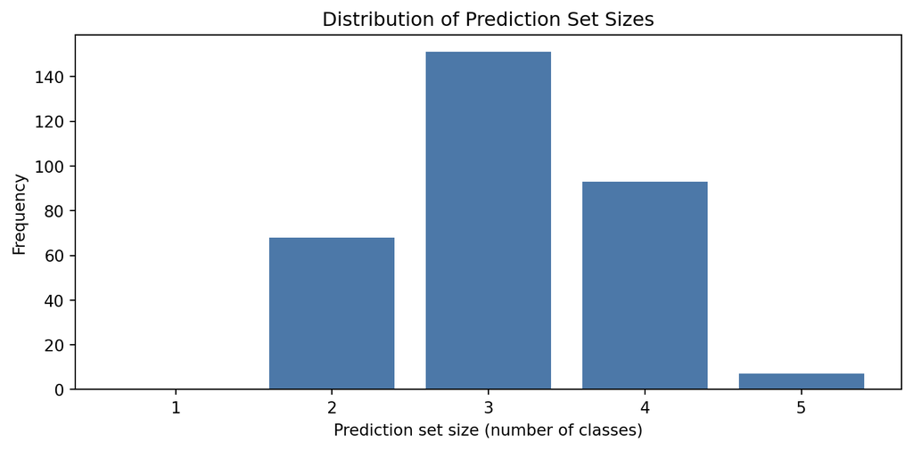

```python
sizes = pred_set.size_by_sample()
fig, ax = plt.subplots(figsize=(8, 4))
ax.hist(sizes, bins=range(1, max(sizes) + 2), align="left", rwidth=0.8, color="#4C78A8")
ax.set_xlabel("Prediction set size (number of classes)")
ax.set_ylabel("Frequency")
ax.set_title("Distribution of Prediction Set Sizes")
plt.tight_layout()
plt.show()
```

## Key Takeaways

| Concept | API |
| --- | --- |
| Auto validation split | `select_validation_plan(df, target, task_type)` |
| Conformal regression | `ConformalRegressor(base_model).fit(df, target).predict(df)` |
| Prediction intervals | `pred.interval(0.9)` |
| Quantiles | `pred.quantile([0.1, 0.5, 0.9])` |
| Samples | `pred.sample(n=500)` |
| Summary | `pred.summary()` |
| Parametric fit | `pred.fit_distribution(family="auto")` |
| All metrics | `pred.crps(y)`, `pred.log_score(y)`, `coverage_score()`, `winkler_score()` |
| Persistence | `model.save(path)` / `ModelClass.load(path)` |
| Classification | `ConformalClassifier(base_model)` → `PredictionSet` |